[figure not shown]

ACCIDENTS AND

ROAD SAFETY For FDS CW2

ROAD TRAFFIC AND ACCIDENTS RESULTING IN A CAUSALITY

[figure not shown]

INTRODUCTION

Road accidents is an issue of concern in every part of world we all know that some

countries have high percentage of death and injuries happened in a road accident.

There are several factors on which it is dependent, and every year government check

the data based on these cases including every factor which is related an accident. In

this project, STATS19 which is a data set released by government has been analysed.

STATS19 is strongly associated with road crashes happened throughout in UK. In this

report, data of accidents, vehicles and casualties will be examined and visualised to

know the reason of these accidents and later come up with a conclusion by using

proposed ideas that how these accidents can be reduced. All the ideas that will be

discussed in this report to reduce accidents will have public interest so that public

can be aware and do more safety measures on basis of what is going to be explained

in this project ideas and accidents severity can be reduced.

[figure not shown]

EVALUATION OF DATA SETS

Evaluation on data sets and analysis is based on following factors

which are in accidents and casualties data for 2016 which are as

follow:

Number of vehicle

Place of accident

Time of accident

Speed of vehicle

Speed limit of particular place

Accident severity

Vehicle Age

ETHICAL, REGULARITY AND PRIVACY

ISSUES

ETHICAL ISSUES: When dealing with big data it is important to keep ethical issues in place

which is systemizing, defending and recommending concepts of right and wrong in relation to

data.

REGULARITY ISSUES: Regulatory Issue is a concern when dealing with data which is

released by an authorized body to provide knowledge about some facts which can be helpful for

other, it is important that human and organizational right would not be violated when working

with this kind of data, in our project, the data provided is vast and released by UK government

for which the regulatory laws should be in place while working on it without violation of any

kind of knowledge.

PRIVACY ISSUES: In big data projects, where dealing with huge amount of data which is

related to big organizations and government bodies like in this one (UK government), data

privacy is an issue which has to include proper handling and not sharing with false person as it

includes huge data of a country including individuals data. There need to be consent, notice and

legal use of data while working on it.

DATA VISUALISATIONS AND

ANALYSIS

using the road safety data on which this project is based on.

IDEA 1: Analysis for pedestrians and cyclists, how vulnerable they have been in accidents.

By (sg611 and ys331)

IDEA 2:Highest accidental region (Top 3) and Correlation of highest contributing factors

with speed limit. Also, Compare them over the years with respect to speed limit? Has the

road safety improved? (By mb331 and kbm11)

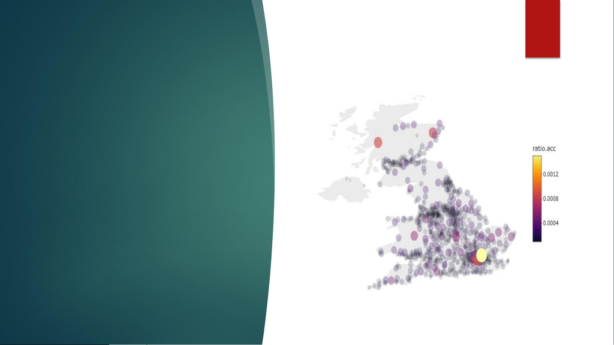

IDEA 1: Analysis for

pedestrians and cyclists, how

vulnerable they have been in

accidents.

As we are aware, most vulnerable road

users to accidents are cyclists and

pedestrians with more chances of severity

during the accident, the reason is no

protection while using the road. A speed

limit of 40 and less than 40 is taken

because those are the only roads which is

used by pedestrians and cyclists.

From the plot above, it can be seen where

and how badly pedestrians and cyclists are

prone to accidents. Most of the incidents

happened in midlands and south of

England where more strict measures need

to be taken in place for more safety of

these users.

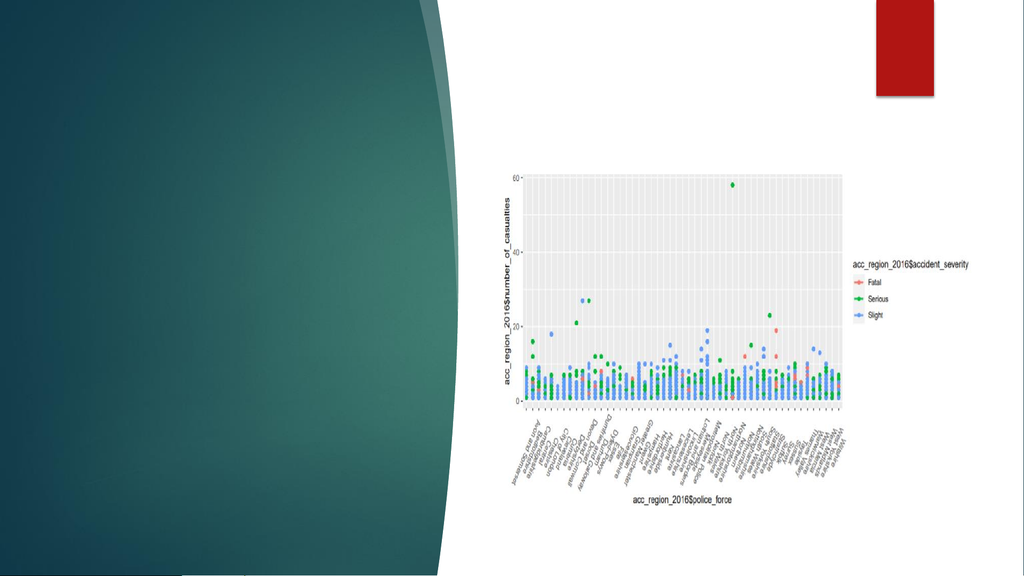

IDEA 2: Highest accidental region (Top 3) and

Correlation of highest contributing factors

with speed limit. Also, Compare them over

the years with respect to speed limit? Has

the road safety improved?

In this idea we have plotted a gg

plot to see where are most highest

taking place and on what seep

limit and what was the severity of

accidents, is it fatal, serious or

slight.

According to the above plot, the

top three regions with highest

Derbyshire.

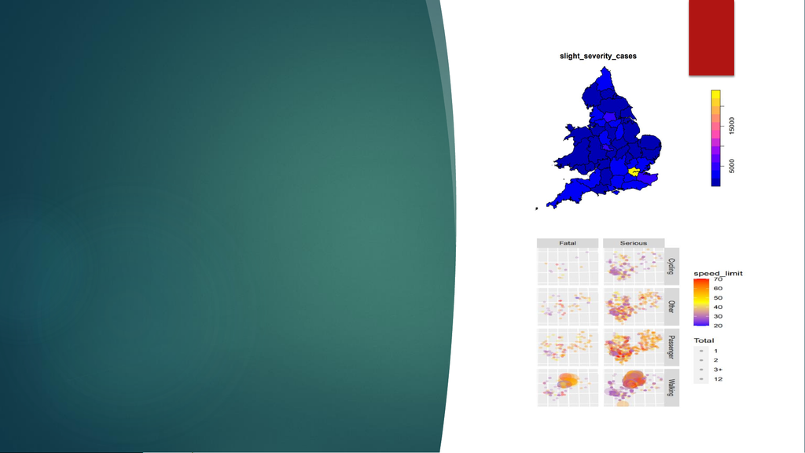

OTHER ANALYSIS

Some basic plots giving the ideas about fatal and

serious accidents happened in 2016 involving

passengers, cyclists, pedestrians and other with a

heat map and on different speeds.

Most vulnerable and people involved in accidents

are Walking and passengers on a speed more than

40 mph.

Another plot for country wide map showing which

place has more severity of the cases in 2016 is

below:

CONCLUSION

After thoroughly considering and evaluating all the data sets

the stats, pedestrians and cyclists appeared to be the most

With more safety measures on road by the public and

government, the rate of accidents or at least severity can be

reduced.

[figure not shown]

FUTURE SCOPE

From all the analysis done so far there are many things which can be done using this data or

different data from stats19. There are several factors need to be focused on to extract more

helpful information and can be more beneficial for public to improve road safety. Several Future

Scope :

Age factor need to be considered by comparing severity of accidents.

Accidents are more fatal when young drivers are on road- could be a reason they have lack of

experience in driving

Data for round abouts and junctions should be analysed because they are most critical points on

road.

For public interest, more strict laws and measures need to be imposed to road more safe.

Analysing top 10 prone areas and examine their numbers and imposing more careful road rules

in those areas.